# Analiza wariancji

6 01 2021

## Wykorzystane dane

Wykorzystujemy dane ze strony *Glownego urzedu statycznego* [link](https://stat.gov.pl/download/gfx/portalinformacyjny/pl/defaultaktualnosci/6285/3/1/1/prawomocnie_skazane_osoby_dorosle.csv). Nasze dane przedstawiaja prawomocnie skazane osoby dorosle. Skazany to osoba fizyczna, która sad uznal winna popelnionego czynu i wymierzyl kare lub srodek karny. Skazany dorosły to osoba skazana, która w momencie popełnienia przestępstwa miała ukończone 17 lat.

## Dane

Screen czesci naszych danych uzytych do projektu

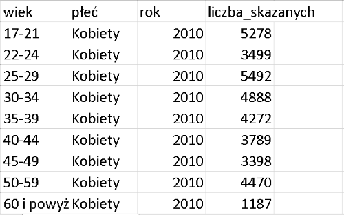

## Analiza wariancji, czyli ANOVA

**Analiza wariancja, ANOVA** jest jedną z najbardziej popularnych i najczęściej stosowanych analiz statystycznych. Metoda ta wyjaśnia, z jakim prawdopodobieństwem wyodrębnione czynniki mogą być powodem różnic między obserwowanymi średnimi grupowymi.

Analiza wariancji została stworzona w latach dwudziestych przez Ronalda Fishera.

Modele analizy wariancji dzielimy na:

- modele jednoczynnikowe
- modele wieloczynnikowe

## Jednoczynnikowa analiza wariancji

W naszym projekcie uzylismy modelu jednoczynnikowego, jak sama nazwa wskazuje, mamy do czynienia tylko z jednym czynnikiem. Chcemy sprawdzic, czy pojedynczy czynnik ma wpływ na mierzoną zmienną zależną.

Do analizy potrzebujemy:

zmienna zalezna - ilosciowa, numeryczna, w naszym przypadku jest to liczba skazanych

zmienna niezalezna - grupująca (dzieli próbę na więcej niż dwie grupy), nominalna, w naszym przypadku sa to lata 2010-2018.

## Hipotezy

### Hipoteza zerowa

Srednie we wszystkich grupach sa rowne.

\[ \begin{aligned} \ H_{0}: \mu_{1} = \mu_{2} = (...) = \mu_{k} \\ \end{aligned} \]

### Hipoteza alternatywna

Srednie pomiedzy grupami roznia sie istotnie.

\[ \begin{aligned} \ H_{1}: \mu_i ≠ \mu_i \end{aligned} \]

## ANOVA - zalozenia

1. Wariancje w grupach są jednorodne
2. Równoliczność obserwacji w podgrupach
3. Rozkład wyników w każdej grupie ma rozkład zbliżony do normalnego

## Statystyki ogolne

```
##    Min. 1st Qu.  Median    Mean 3rd Qu.    Max.
##      10    3094    4746   16554   30412   73155
```

## Histogram

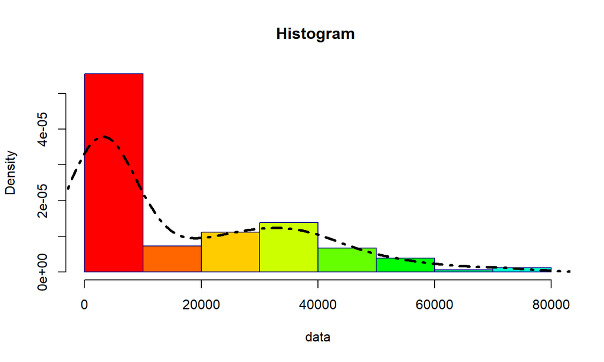

## Wykres pudelkowy

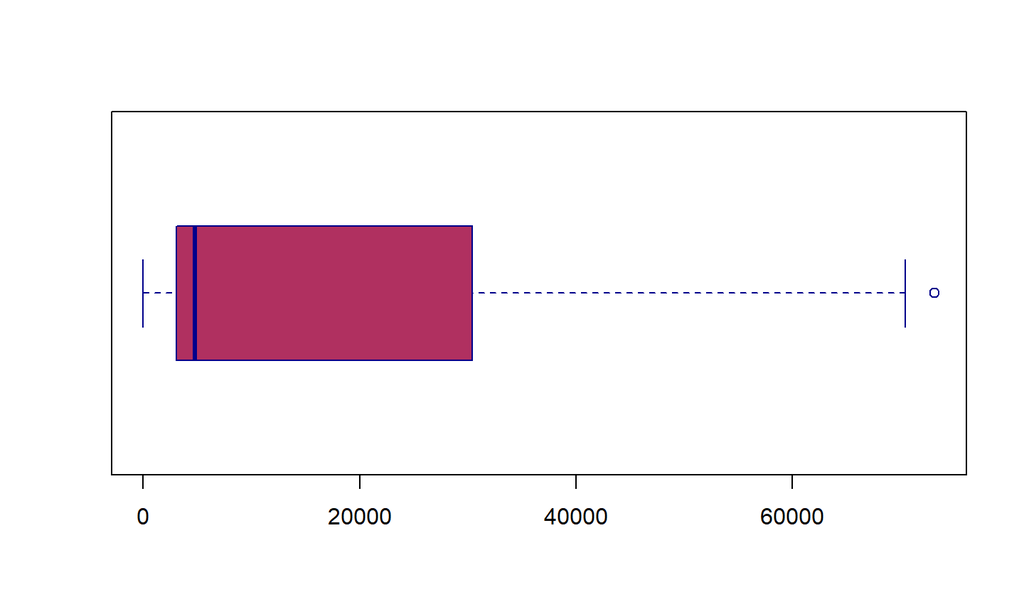

## Srednie i wariancje

Liczymy srednie i wariancje z kazdego roku. Uzywajac funkcji *tapply()*, *mean()* i *ver()*

```r
tapply(s$liczba_skazanych, s$rok, mean)
```

```
##     2010     2011     2012     2013     2014     2015     2016     2017
## 21644.55 21173.20 20405.35 17660.40 14767.65 13001.70 14475.60 12071.80
##     2018
## 13788.40
```

```r
tapply(s$liczba_skazanych, s$rok, var)
```

```
##      2010      2011      2012      2013      2014      2015      2016      2017
## 554237560 528275813 487259311 353144620 241890369 181148459 225309522 150734553
##      2018
## 203763005
```

## Wykres pudelkowy

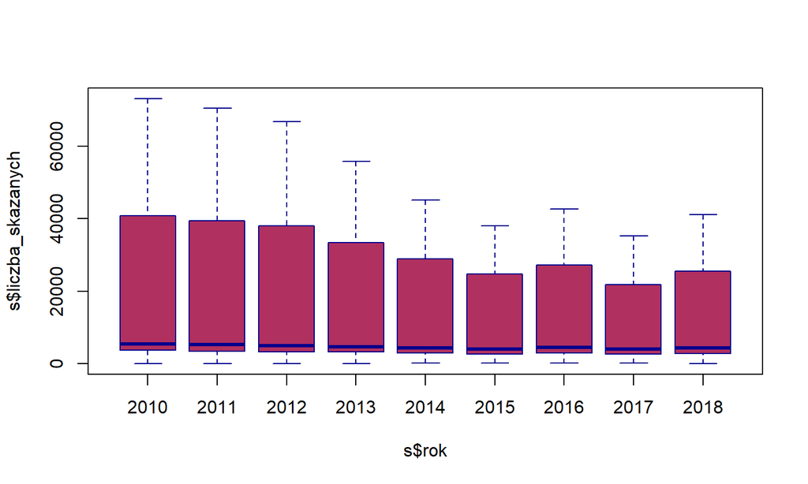

## Testy ANOVA (1)

Na poczatku sprawdzamy czy srednie sa sobie rowne, nie zakladajac rownosci wariancji. Uzywamy funkcji *oneway.test()*

```r
oneway.test(s$liczba_skazanych ~ s$rok)
```

```
##
##  One-way analysis of means (not assuming equal variances)
##
## data:  s$liczba_skazanych and s$rok
## F = 0.74876, num df = 8.000, denom df = 71.042, p-value = 0.6484
```

## Testy ANOVA (2)

Nastepnie sprawdzamy czy srednie i wariancje sa rowne. Rowniez uzywajac *oneway.test* ale na koncu zmieniajac na *var.equal = T*

```r
oneway.test(s$liczba_skazanych ~ s$rok, var.equal = T)
```

```
##
##  One-way analysis of means
##
## data:  s$liczba_skazanych and s$rok
## F = 0.85498, num df = 8, denom df = 171, p-value = 0.5558
```

## Testy ANOVA (3)

W jednoczynnikowej analize wariancji modelujemy liczbe skazanych w zaleznosci od roku. Najpierw uzywamy *aov()* do uruchomienia modelu, potem *summary()* do wyswietlenia podsumowania operacji.

```r
aov.out <- aov(s$liczba_skazanych ~ s$rok, data = s)
         summary(aov.out)
```

```
##              Df    Sum Sq   Mean Sq F value Pr(>F)
## s$rok         8 2.224e+09 277940033   0.855  0.556
## Residuals   171 5.559e+10 325084801
```

## Testy ANOVA (4)

**ANOVA** mowi nam, czy sa roznice miedzy srednimi grupowymi, ale nie mowi jakie sa roznice. Aby dowiedziec sie, ktore grupy sa statystycznie rozne od siebie, przeprowadzimy test post-hoc *TukeyHSD()*.

```r
aov.out <- aov(s$liczba_skazanych ~ s$rok, data = s)
         TukeyHSD(aov.out)
```

## Testy ANOVA (4)

```
##   Tukey multiple comparisons of means
##     95% family-wise confidence level
##
## Fit: aov(formula = s$liczba_skazanych ~ s$rok, data = s)
##
## $`s$rok`
##               diff       lwr       upr     p adj
## 2011-2010  -471.35 -18385.59 17442.886 1.0000000
## 2012-2010 -1239.20 -19153.44 16675.036 0.9999998
## 2013-2010 -3984.15 -21898.39 13930.086 0.9987531
## 2014-2010 -6876.90 -24791.14 11037.336 0.9542325
## 2015-2010 -8642.85 -26557.09  9271.386 0.8467551
## 2016-2010 -7168.95 -25083.19 10745.286 0.9419780
## 2017-2010 -9572.75 -27486.99  8341.486 0.7585166
## 2018-2010 -7856.15 -25770.39 10058.086 0.9047034
## 2012-2011  -767.85 -18682.09 17146.386 1.0000000
## 2013-2011 -3512.80 -21427.04 14401.436 0.9995019
## 2014-2011 -6405.55 -24319.79 11508.686 0.9699418
## 2015-2011 -8171.50 -26085.74  9742.736 0.8834381
## 2016-2011 -6697.60 -24611.84 11216.636 0.9607743
## 2017-2011 -9101.40 -27015.64  8812.836 0.8056903
## 2018-2011 -7384.80 -25299.04 10529.436 0.9315801
## 2013-2012 -2744.95 -20659.19 15169.286 0.9999217
## 2014-2012 -5637.70 -23551.94 12276.536 0.9864852
## 2015-2012 -7403.65 -25317.89 10510.586 0.9306162
## 2016-2012 -5929.75 -23843.99 11984.486 0.9813454
## 2017-2012 -8333.55 -26247.79  9580.686 0.8714820
## 2018-2012 -6616.95 -24531.19 11297.286 0.9634852
## 2014-2013 -2892.75 -20806.99 15021.486 0.9998834
## 2015-2013 -4658.70 -22572.94 13255.536 0.9962348
## 2016-2013 -3184.80 -21099.04 14729.436 0.9997595
## 2017-2013 -5588.60 -23502.84 12325.636 0.9872286
## 2018-2013 -3872.00 -21786.24 14042.236 0.9989854
## 2015-2014 -1765.95 -19680.19 16148.286 0.9999974
## 2016-2014  -292.05 -18206.29 17622.186 1.0000000
## 2017-2014 -2695.85 -20610.09 15218.386 0.9999318
## 2018-2014  -979.25 -18893.49 16934.986 1.0000000
## 2016-2015  1473.90 -16440.34 19388.136 0.9999994
## 2017-2015  -929.90 -18844.14 16984.336 1.0000000
## 2018-2015   786.70 -17127.54 18700.936 1.0000000
## 2017-2016 -2403.80 -20318.04 15510.436 0.9999717
## 2018-2016  -687.20 -18601.44 17227.036 1.0000000
## 2018-2017  1716.60 -16197.64 19630.836 0.9999979
```

## Weryfikacja zalozen

### Wariancje w grupach sa jednorodne

Na koncu wykonujemy weryfikacje wczesniejszych zalozen. Wykonujemy test Bartletta *bartlett.test()* ktory sprawdza czy wariancje w kazdej z grup są takie same.

```
##
##  Bartlett test of homogeneity of variances
##
## data:  s$liczba_skazanych by s$rok
## Bartlett's K-squared = 18.192, df = 8, p-value = 0.01983
```

## Weryfikacja zalozen

### Rozklad wynikow w każdej grupie ma rozklad zblizony do normalnego

Wykonujemy test Sharipo-Wilk *shapiro.test()* na sprawdzenie czy rozklad wynikow jest zblizony do normalnego w kazdej grupie

```
## $`2010`
##
##  Shapiro-Wilk normality test
##
## data:  X[[i]]
## W = 0.81771, p-value = 0.001606
##
##
## $`2011`
##
##  Shapiro-Wilk normality test
##
## data:  X[[i]]
## W = 0.8191, p-value = 0.001688
##
##
## $`2012`
##
##  Shapiro-Wilk normality test
##
## data:  X[[i]]
## W = 0.82113, p-value = 0.001816
##
##
## $`2013`
##
##  Shapiro-Wilk normality test
##
## data:  X[[i]]
## W = 0.82236, p-value = 0.001899
##
##
## $`2014`
##
##  Shapiro-Wilk normality test
##
## data:  X[[i]]
## W = 0.81931, p-value = 0.001701
##
##
```

[output cut: 15 more lines]

```
##
## $`2017`
##
##  Shapiro-Wilk normality test
##
## data:  X[[i]]
## W = 0.82626, p-value = 0.002188
##
##
## $`2018`
##
##  Shapiro-Wilk normality test
##
## data:  X[[i]]
## W = 0.82506, p-value = 0.002094
```